# Practical Machine Learning Project

Andrey Ivanov

16 04 2020

## Synopsis

The goal of the study is to predict the manner in which people do excercises using data from accelerometers on the belt, forearm, arm, and dumbell of 6 participants.  
The main data set stored in pml-training.csv file, it’s labeled with “classe” variable.  
There is data set pml-testing.csv with 20 observations which should be predicted using prediction model.

## 1. Exploratory data analysis.

Let’s load the data and look at it:

```r
pml.training <- read.csv("pml-training.csv")
pml.testing <- read.csv("pml-testing.csv")
```

- First of all pml.training data set should be split on training and testing data using createDataPartition() function (set.seed() function used for reproducibility purpose):

```r
library(caret)
set.seed(2435)
inTrain <- createDataPartition(y=pml.training$classe, p=.75, list=FALSE)
training <- pml.training[inTrain,]
testing <- pml.training[-inTrain,]
```

```r
dim(pml.training)
```

```
## [1] 19622   160
```

```r
str(pml.training[,c(0:20,160)])
```

```
## 'data.frame':    19622 obs. of  21 variables:
##  $ X                   : int  1 2 3 4 5 6 7 8 9 10 ...
##  $ user_name           : Factor w/ 6 levels "adelmo","carlitos",..: 2 2 2 2 2 2 2 2 2 2 ...
##  $ raw_timestamp_part_1: int  1323084231 1323084231 1323084231 1323084232 1323084232 1323084232 1323084232 1323084232 1323084232 1323084232 ...
##  $ raw_timestamp_part_2: int  788290 808298 820366 120339 196328 304277 368296 440390 484323 484434 ...
##  $ cvtd_timestamp      : Factor w/ 20 levels "02/12/2011 13:32",..: 9 9 9 9 9 9 9 9 9 9 ...
##  $ new_window          : Factor w/ 2 levels "no","yes": 1 1 1 1 1 1 1 1 1 1 ...
##  $ num_window          : int  11 11 11 12 12 12 12 12 12 12 ...
##  $ roll_belt           : num  1.41 1.41 1.42 1.48 1.48 1.45 1.42 1.42 1.43 1.45 ...
##  $ pitch_belt          : num  8.07 8.07 8.07 8.05 8.07 8.06 8.09 8.13 8.16 8.17 ...
##  $ yaw_belt            : num  -94.4 -94.4 -94.4 -94.4 -94.4 -94.4 -94.4 -94.4 -94.4 -94.4 ...
##  $ total_accel_belt    : int  3 3 3 3 3 3 3 3 3 3 ...
##  $ kurtosis_roll_belt  : Factor w/ 397 levels "","-0.016850",..: 1 1 1 1 1 1 1 1 1 1 ...
##  $ kurtosis_picth_belt : Factor w/ 317 levels "","-0.021887",..: 1 1 1 1 1 1 1 1 1 1 ...
##  $ kurtosis_yaw_belt   : Factor w/ 2 levels "","#DIV/0!": 1 1 1 1 1 1 1 1 1 1 ...
##  $ skewness_roll_belt  : Factor w/ 395 levels "","-0.003095",..: 1 1 1 1 1 1 1 1 1 1 ...
##  $ skewness_roll_belt.1: Factor w/ 338 levels "","-0.005928",..: 1 1 1 1 1 1 1 1 1 1 ...
##  $ skewness_yaw_belt   : Factor w/ 2 levels "","#DIV/0!": 1 1 1 1 1 1 1 1 1 1 ...
##  $ max_roll_belt       : num  NA NA NA NA NA NA NA NA NA NA ...
##  $ max_picth_belt      : int  NA NA NA NA NA NA NA NA NA NA ...
##  $ max_yaw_belt        : Factor w/ 68 levels "","-0.1","-0.2",..: 1 1 1 1 1 1 1 1 1 1 ...
##  $ classe              : Factor w/ 5 levels "A","B","C","D",..: 1 1 1 1 1 1 1 1 1 1 ...
```

- There are 19622 observations with 160 variables. Lets try to redice dimentions of future model.
- First: there are first seven variables, that doesn’t relate to outcome. “classe” relates only to the signals from accelerometers. Let’s rid off them.
- Second: there are a lot of variables with NA or emty values across all the observations. Let’s indicate and erase them as well.

```r
training <- training[, -c(1:7)]
testing <- testing[, -c(1:7)]
pml.testing <- pml.testing[, -c(1:7)]

NAcols <- which(colSums(is.na(training) | training == "")/dim(training)[1] > 0.95)
training <- training[, -NAcols]
testing  <- testing[, -NAcols]
pml.testing  <- pml.testing[, -NAcols]
dim(pml.training)
```

```
## [1] 19622   160
```

## 2. Building a model.

- caret package will be used through all the process.
- This prdiction task is classification between 5 classes. Let’s use Random Forest model.
- Cross validation with 5 subsamples will be used to reduce out-of-sample errors.

```r
control_rf <- trainControl(method="cv", number=5, verboseIter=FALSE)
```

- Fit the model random forest model (method=“rf”) with “classe” as outcome and all the remaining parameters as predictors. trControl defines cross validation process in the model.

```r
set.seed(1518)
model_rf <- train(classe ~ ., data = training, method = "rf", trControl = control_rf)
```

- Let’s look at the model.

```r
print(model_rf)
```

```
## Random Forest
##
## 14718 samples
##    52 predictor
##     5 classes: 'A', 'B', 'C', 'D', 'E'
##
## No pre-processing
## Resampling: Cross-Validated (5 fold)
## Summary of sample sizes: 11775, 11774, 11775, 11775, 11773
## Resampling results across tuning parameters:
##
##   mtry  Accuracy   Kappa
##    2    0.9916429  0.9894277
##   27    0.9912351  0.9889120
##   52    0.9816543  0.9767904
##
## Accuracy was used to select the optimal model using the largest value.
## The final value used for the model was mtry = 2.
```

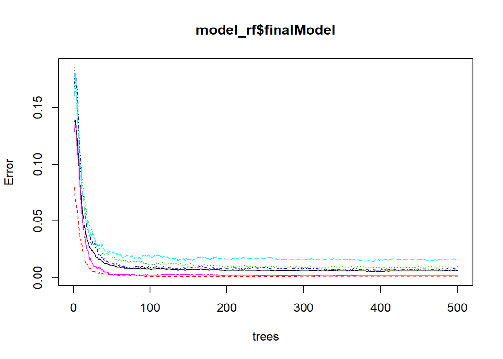

```r
plot(model_rf$finalModel)
```

- Maximum Model’s accuracy is 99.2% with number of variables in each split mrty = 2  
  and number of trees: 500
- Let’s check out-of-sample error using testing data set:

```r
pred_rf <- predict(model_rf, newdata=testing)
confusionMatrix(pred_rf, testing$classe)
```

```
## Confusion Matrix and Statistics
##
##           Reference
## Prediction    A    B    C    D    E
##          A 1395    4    0    0    0
##          B    0  943   10    0    0
##          C    0    2  845   18    4
##          D    0    0    0  785    1
##          E    0    0    0    1  896
##
## Overall Statistics
##
##                Accuracy : 0.9918
##                  95% CI : (0.9889, 0.9942)
##     No Information Rate : 0.2845
##     P-Value [Acc > NIR] : < 2.2e-16
##
##                   Kappa : 0.9897
##
##  Mcnemar's Test P-Value : NA
##
## Statistics by Class:
##
##                      Class: A Class: B Class: C Class: D Class: E
## Sensitivity            1.0000   0.9937   0.9883   0.9764   0.9945
## Specificity            0.9989   0.9975   0.9941   0.9998   0.9998
## Pos Pred Value         0.9971   0.9895   0.9724   0.9987   0.9989
## Neg Pred Value         1.0000   0.9985   0.9975   0.9954   0.9988
## Prevalence             0.2845   0.1935   0.1743   0.1639   0.1837
## Detection Rate         0.2845   0.1923   0.1723   0.1601   0.1827
## Detection Prevalence   0.2853   0.1943   0.1772   0.1603   0.1829
## Balanced Accuracy      0.9994   0.9956   0.9912   0.9881   0.9971
```

- Predictions’ accuracy is 99.18% . So Random Forest model is good for this job.
- Expected out of sample error is 0.82%

## 3. Making Predictions.

- Let’s predict classes of 20 data samples from pml.testing:

```r
fin_preds <- predict(model_rf, newdata=pml.testing)
fin_preds
```

```
##  [1] B A B A A E D B A A B C B A E E A B B B
## Levels: A B C D E
```